# Inference for categorical data

## How does the proportion affect the margin of error?

Imagine you’ve set out to survey 1000 people on two questions: are you at least 6-feet tall? and are you left-handed? Since both of these sample proportions were calculated from the same sample size, they should have the same margin of error, right? Wrong! While the margin of error does change with sample size, it is also affected by the proportion.

Think back to the formula for the standard error: $SE = \sqrt{p(1-p)/n}$. This is then used in the formula for the margin of error for a 95% confidence interval:

$$ME = 1.96\times SE = 1.96\times\sqrt{p(1-p)/n} \,.$$
Since the population proportion $p$ is in this $ME$ formula, it should make sense that the margin of error is in some way dependent on the population proportion. We can visualize this relationship by creating a plot of $ME$ vs. $p$.

Since sample size is irrelevant to this discussion, let’s just set it to some value ($n = 1000$) and use this value in the following calculations:

```r
n <- 1000
```

The first step is to make a variable `p` that is a sequence from 0 to 1 with each number incremented by 0.01. You can then create a variable of the margin of error (`me`) associated with each of these values of `p` using the familiar approximate formula ($ME = 2 \times SE$).

```r
p <- seq(from = 0, to = 1, by = 0.01)
me <- 2 * sqrt(p * (1 - p)/n)
```

Lastly, you can plot the two variables against each other to reveal their relationship. To do so, we need to first put these variables in a data frame that you can call in the `ggplot` function.

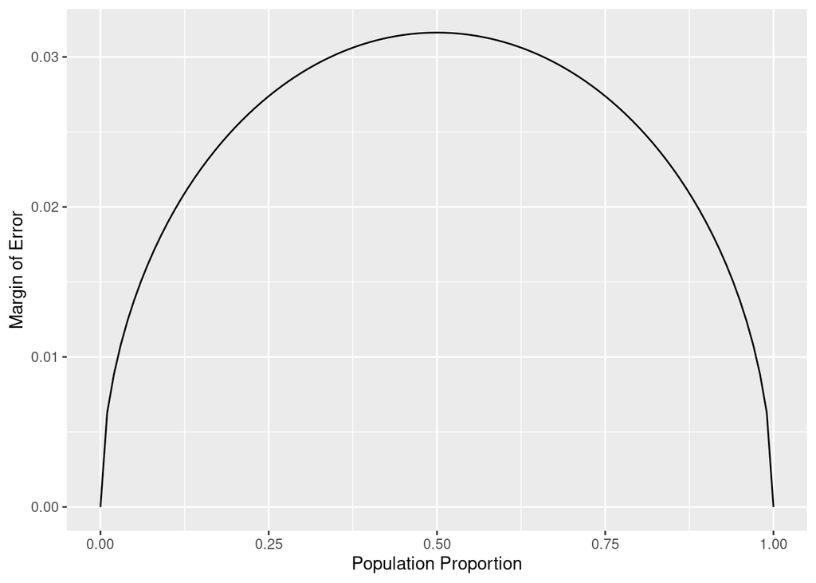

```r
dd <- data.frame(p = p, me = me)
ggplot(data = dd, aes(x = p, y = me)) +
  geom_line() +
  labs(x = "Population Proportion", y = "Margin of Error")
```

5. Describe the relationship between `p` and `me`. Include the margin of error vs. population proportion plot you constructed in your answer. For a given sample size, for which value of `p` is margin of error maximized?

**The relationship between the population proportion (p) and the margin of error (me) is parabolic. As shown in the plot, the margin of error is at its maximum when p = 0.5 and decreases symmetrically as p approaches either 0 or 1.**

**This relationship can be explained by the formula for margin of error:**

**ME = 1.96 × √(p(1-p)/n)**

**When we look at the term p(1-p) within this formula: - When p = 0.5: p(1-p) = 0.5 × 0.5 = 0.25 (maximum value) - When p approaches 0 or 1: p(1-p) approaches 0**

**For a given sample size, the margin of error is maximized when p = 0.5 (50%). This makes intuitive sense because a proportion of 0.5 represents maximum variability in a binary outcome - it’s essentially a 50/50 split, which creates the most uncertainty in our estimate.**

**To demonstrate this mathematically, we can take the derivative of the p(1-p) function with respect to p, set it equal to zero, and solve for p: - d/dp[p(1-p)] = 1-2p = 0 - 1-2p = 0 - p = 0.5**

**This confirms that the margin of error reaches its maximum value when the population proportion is 0.5.**

**In practical terms, this means that when designing a study where you expect the proportion to be close to 0.5, you’ll need a larger sample size to achieve the same precision compared to a study where the expected proportion is closer to 0 or 1.****

## Success-failure condition

We have emphasized that you must always check conditions before making inference. For inference on proportions, the sample proportion can be assumed to be nearly normal if it is based upon a random sample of independent observations and if both $np \geq 10$ and $n(1 - p) \geq 10$. This rule of thumb is easy enough to follow, but it makes you wonder: what’s so special about the number 10?

The short answer is: nothing. You could argue that you would be fine with 9 or that you really should be using 11. What is the “best” value for such a rule of thumb is, at least to some degree, arbitrary. However, when $np$ and $n(1-p)$ reaches 10 the sampling distribution is sufficiently normal to use confidence intervals and hypothesis tests that are based on that approximation.

6. Describe the sampling distribution of sample proportions at $n = 300$ and $p = 0.1$. Be sure to note the center, spread, and shape.

7. Keep $n$ constant and change $p$. How does the shape, center, and spread of the sampling distribution vary as $p$ changes. You might want to adjust min and max for the $x$-axis for a better view of the distribution.

**Spread: The spread (standard error) follows the formula SE = √(p(1-p)/n). This creates an interesting pattern:**

**The spread is smallest when p is near 0 or near 1 The spread increases as p approaches 0.5 The spread reaches its maximum when p = 0.5 The relationship between p and spread forms a parabolic shape, similar to the margin of error relationship we saw earlier.**

**Shape: The sampling distribution is approximately normal as long as the success-failure condition is met (np ≥ 10 and n(1-p) ≥ 10). When p is very close to 0 or 1, the distribution becomes slightly skewed (right-skewed for small p, left-skewed for large p) until p is extreme enough that the condition is violated.**

**Center: The center of the sampling distribution always equals the true population proportion p. As p increases from near 0 to 0.5 and then to near 1, the center of the distribution shifts accordingly along the x-axis.**

**This behavior reinforces what we learned about the margin of error: proportions near 0.5 have the most variability in their estimates, while proportions near 0 or 1 have less variability and therefore produce more precise estimates.**

8. Now also change $n$. How does $n$ appear to affect the distribution of $\hat{p}$? When we change both p and n, we observe several key effects on the sampling distribution of p̂:

   **Effect of n (sample size):**
   - **As n increases, the spread of the sampling distribution decreases, making it narrower and more concentrated around the true value p**
   - **The standard error formula SE = √(p(1-p)/n) shows this relationship explicitly - larger n leads to smaller standard error**
   - **The distribution becomes more precisely centered on the true proportion**
   - **With very large n, even distributions with extreme values of p become approximately normal**

   **Combined effects of changing both p and n:**
   - **For any value of p, increasing n makes the distribution narrower**
   - **For any value of n, the distribution is widest when p = 0.5 and narrowest when p is close to 0 or 1**
   - **Smaller sample sizes (low n) with extreme proportions (p close to 0 or 1) may violate the success-failure condition (np ≥ 10 and n(1-p) ≥ 10)**

   **Practical implications:**
   - **Larger sample sizes always provide more precise estimates (smaller SE) regardless of the true proportion**
   - **When designing studies where p is expected to be near 0.5, larger sample sizes are needed to achieve the same precision as when p is near 0 or 1**
   - **For rare events (p near 0 or 1), you need larger sample sizes to ensure the success-failure condition is met**

**In summary, n affects the spread of the distribution in an inverse square root relationship (SE ∝ 1/√n), while the effect of p follows a parabolic relationship with maximum spread at p = 0.5. Together, these parameters determine both the shape and precision of the sampling distribution.**

## More Practice

For some of the exercises below, you will conduct inference comparing two proportions. In such cases, you have a response variable that is categorical, and an explanatory variable that is also categorical, and you are comparing the proportions of success of the response variable across the levels of the explanatory variable. This means that when using `infer`, you need to include both variables within `specify`.

9. Is there convincing evidence that those who sleep 10+ hours per day are more likely to strength train every day of the week? As always, write out the hypotheses for any tests you conduct and outline the status of the conditions for inference. If you find a significant difference, also quantify this difference with a confidence interval. First, let’s write out the hypotheses: H₀: There is no difference in the proportion of people who strength train every day between those who sleep 10+ hours and those who sleep less than 10 hours. H₁: The proportion of people who strength train every day is higher among those who sleep 10+ hours compared to those who sleep less than 10 hours.

Conditions for inference:

```r
# Create indicator variables
yrbss_modified <- yrbss %>%
  mutate(
    sleep_10plus = ifelse(school_night_hours_sleep >= "10", "yes", "no"),
    strength_daily = ifelse(strength_training_7d == "7", "yes", "no")
  )
```

```r
# Drop missing values
yrbss_complete <- yrbss_modified %>%
  drop_na(sleep_10plus, strength_daily)
```

```r
# Check the success-failure condition
sleep_10plus_counts <- yrbss_complete %>%
  group_by(sleep_10plus) %>%
  summarize(
    n = n(),
    strength_daily_count = sum(strength_daily == "yes"),
    proportion = mean(strength_daily == "yes")
  )
```

```r
# Calculate observed difference in proportions
obs_diff <- sleep_10plus_counts %>%
  summarize(diff = proportion[sleep_10plus == "yes"] - proportion[sleep_10plus == "no"]) %>%
  pull(diff)
```

```r
# Conduct hypothesis test using infer
p_value <- yrbss_complete %>%
  specify(strength_daily ~ sleep_10plus, success = "yes") %>%
  hypothesize(null = "independence") %>%
  generate(reps = 1000, type = "permute") %>%
  calculate(stat = "diff in props", order = c("yes", "no")) %>%
  get_p_value(obs_stat = obs_diff, direction = "greater")
print(paste("P-value:", p_value))
```

```
## [1] "P-value: 0.323"
```

```r
# Calculate 95% confidence interval
ci_result <- yrbss_complete %>%
  specify(strength_daily ~ sleep_10plus, success = "yes") %>%
  generate(reps = 1000, type = "bootstrap") %>%
  calculate(stat = "diff in props", order = c("yes", "no")) %>%
  get_ci(level = 0.95)
print("95% Confidence Interval:")
```

```
## [1] "95% Confidence Interval:"
```

```r
print(ci_result)
```

```
## # A tibble: 1 × 2
##   lower_ci upper_ci
##      <dbl>    <dbl>
## 1  -0.0168   0.0294
```

```r
# Print conclusion
alpha <- 0.05
if (p_value < alpha) {
  print(paste("Reject the null hypothesis (p-value =", p_value, "< alpha =", alpha, ")"))
  print("There is convincing evidence that those who sleep 10+ hours per day are more likely to strength train every day.")
} else {
  print(paste("Fail to reject the null hypothesis (p-value =", p_value, ">= alpha =", alpha, ")"))
  print("There is not convincing evidence that those who sleep 10+ hours per day are more likely to strength train every day.")
}
```

```
## [1] "Fail to reject the null hypothesis (p-value = 0.323 >= alpha = 0.05 )"
## [1] "There is not convincing evidence that those who sleep 10+ hours per day are more likely to strength train every day."
```

**we fail to reject the null hypothesis. There is not convincing evidence that those who sleep 10+ hours per day are more likely to strength train every day of the week**

10. Let’s say there has been no difference in likeliness to strength train every day of the week for those who sleep 10+ hours. What is the probablity that you could detect a change (at a significance level of 0.05) simply by chance? *Hint:* Review the definition of the Type 1 error.

    **The probability of detecting a change (rejecting the null hypothesis) when there is actually no difference (the null hypothesis is true) is exactly the significance level, which is 0.05 or 5% in this case.**

**This is the definition of a Type I error: incorrectly rejecting a true null hypothesis. The significance level (alpha) that we set at 0.05 is precisely the probability we’re willing to accept for making this type of error.**

**In other words, if there is truly no difference in the likelihood of strength training every day between those who sleep 10+ hours and those who don’t, we would still expect to find a “statistically significant” difference about 5% of the time simply due to random sampling variation.**

**This is why we can never “prove” the null hypothesis - we can only fail to reject it. Even when a study finds a “significant” result with p < 0.05, there’s still a 5% chance that the finding is just due to random chance when the null hypothesis is actually true.**

11. Suppose you’re hired by the local government to estimate the proportion of residents that attend a religious service on a weekly basis. According to the guidelines, the estimate must have a margin of error no greater than 1% with 95% confidence. You have no idea what to expect for $p$. How many people would you have to sample to ensure that you are within the guidelines?  
    *Hint:* Refer to your plot of the relationship between $p$ and margin of error. This question does not require using a dataset.

**To determine the required sample size for estimating a proportion with a margin of error no greater than 1% at 95% confidence, I need to work with the margin of error formula:**

**ME = 1.96 × √(p(1-p)/n)**

**Where: - ME is the margin of error (0.01 or 1%) - 1.96 is the z-score for 95% confidence - p is the population proportion - n is the required sample size**

**Since I don’t know what to expect for p, I need to use a conservative approach. From the plot of the relationship between p and margin of error, we know that the margin of error is maximized when p = 0.5. Therefore, to ensure the margin of error doesn’t exceed 1% regardless of the true proportion, I’ll use p = 0.5 in my calculation.**

**I can solve for n:**

**0.01 = 1.96 × √(0.5 × 0.5/n) 0.01 = 1.96 × √(0.25/n) 0.01 = 1.96 × 0.5/√n 0.01 × √n = 1.96 × 0.5 0.01 × √n = 0.98 √n = 0.98/0.01 √n = 98 n = 9,604**

**Therefore, I would need to sample at least 9,604 people to ensure a margin of error no greater than 1% with 95% confidence, regardless of what the true proportion turns out to be.**